# Exploratory data analysis

Evgenii Berdinskikh, Marina Kozyreva, Anton Tikhonenko

2025-01-28

## Data import

```r
## Ambulance Data related to acute cerebrovascular accidents
brain_data <- read_csv("data/raw/brain_data.csv") %>%
   mutate(across(c(Year, Season, Month, DayOff, COVID, Sudden_Start, Dst_level), as.factor))
## Ambulance Long Data related to acute cerebrovascular accidents
brain_data_long <- read_csv("data/raw/brain_data_long.csv") %>%
    mutate(across(c(Year, Season, Month, DayOff, COVID, Sudden_Start, Dst_level, Sex, Age), as.factor))

## Ambulance Data related to cardiovascular diseases
heart_data <- read_csv("data/raw/heart_data.csv") %>%
   mutate(across(c(Year, Season, Month, DayOff, COVID, Sudden_Start, Dst_level), as.factor))
## Ambulance Long Data  related to unstable angina
UA_data_long <- read_csv("data/raw/UA_data_long.csv") %>%
   mutate(across(c(Year, Season, Month, DayOff, COVID, Sudden_Start, Dst_level, Sex, Age), as.factor))
## Ambulance Long Data related to acute myocardial infarction
AMI_data_long <- read_csv("data/raw/AMI_data_long.csv") %>%
   mutate(across(c(Year, Season, Month, DayOff, COVID, Sudden_Start, Dst_level, Sex, Age), as.factor))
```

## Correlation of qualitative variables

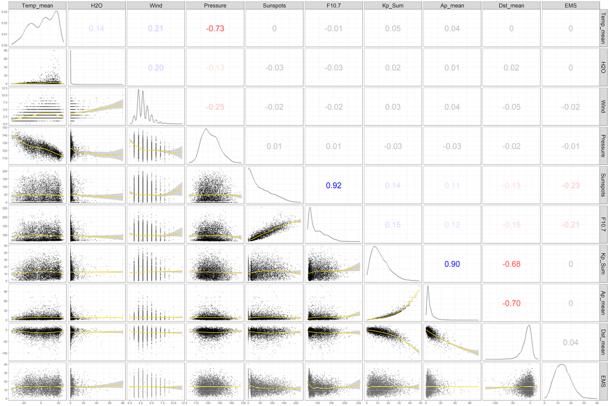

```r
# Data preprocessing
brain_data_clear <- brain_data %>%
  select( where(is.numeric) & !ends_with(c("min", "max", "var", "K_Sum")) ) %>%
  filter(complete.cases(.))

# Function for displaying correlations with a neutral color for values close to 0
color_correlation_fixed <- function(data, mapping, ...) {

  x <- eval_data_col(data, mapping$x)
  y <- eval_data_col(data, mapping$y)
  cor_value <- cor(x, y, use = "complete.obs")

  # Defining color
  color <- if (abs(cor_value) < 0.1) {
    scales::alpha("gray50", 0.5)           ## Gray for weak correlations
  } else if (cor_value > 0) {
    scales::alpha("blue", abs(cor_value))  ## Blue for positive correlations
  } else {
    scales::alpha("red", abs(cor_value))   ## Red for negative correlations
  }

  # Filter for small correlation values
  cor_label <- ifelse(abs(cor_value) < 0.01, "0", sprintf("%.2f", cor_value))

  ggplot(data.frame()) +
    annotate("text", x = 0.5, y = 0.5, label = cor_label, size = 10, color = color ) +
    theme_void()
}

# Function for trend line with a golden color
golden_smooth <- function(data, mapping, ...) {
  ggplot(data, mapping) +
    geom_point(alpha = 0.4, size = 0.5, color = "black") +
    geom_smooth(color = "gold", ...) +
    theme_custom
}

# Plot construction
ggpairs(
  brain_data_clear,
  progress = FALSE,
  upper = list(continuous = color_correlation_fixed), ## Highlighting correlations
  lower = list(continuous = golden_smooth) )+         ## Golden trend line
theme_custom +
  theme(
    axis.text.x = element_text(size = 10),
    axis.text.y = element_text(size = 10) )
```

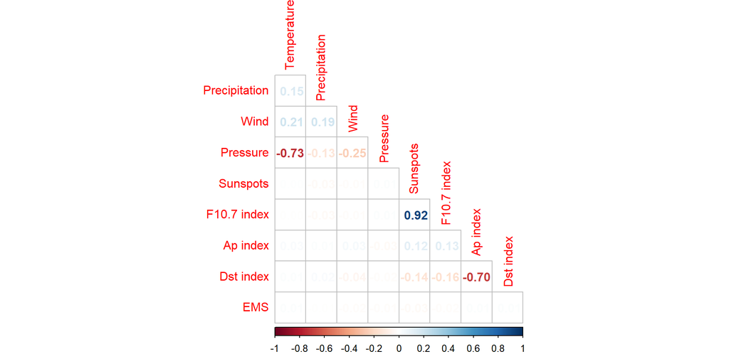

```r
cor_data <- brain_data %>%
  select( where(is.numeric) & !ends_with(c("min", "max", "Sum", "var")) ) %>%
  rename(Temperature = Temp_mean, Precipitation = H2O,
         `F10.7 index` = F10.7, `Ap index` = Ap_mean, `Dst index` = Dst_mean) %>%
  cor(use = "pairwise.complete.obs")

corrplot(cor_data, method = 'number', type = 'lower', diag = FALSE)
```

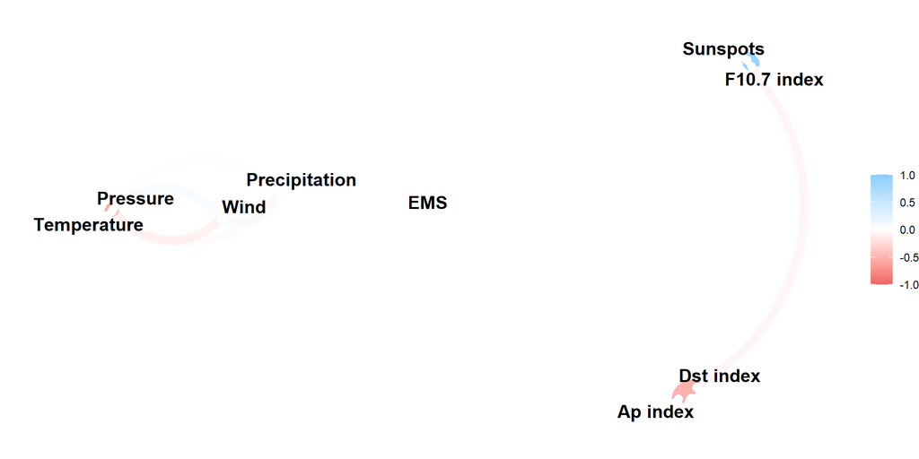

```r
network_plot(cor_data, min_cor = .1)
```

When analyzing the network graph, three groups of features can be identified:

- Climatic: temperature, pressure, wind, precipitation;
- Geomagnetic: Dst index, Ap index;
- Solar: F10.7 index, number of sunspots.

Additionally, some features within the groups exhibit a high degree of correlation!

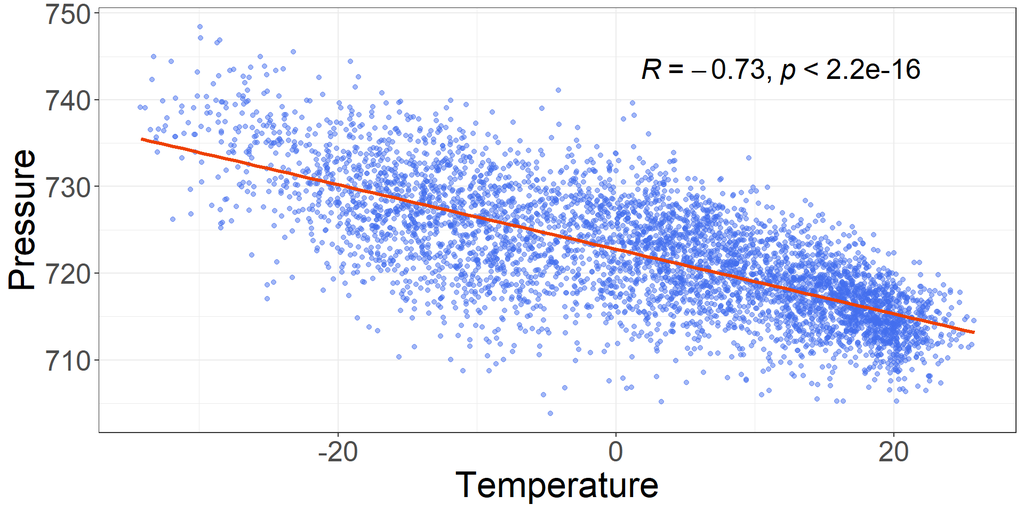

```r
brain_data %>%
  drop_na() %>%
  ggplot(aes(Temp_mean, Pressure))+
  geom_jitter(alpha = 0.5, colour = "royalblue2", size = 1.5)+
  geom_smooth(method = "lm", se = FALSE, colour = "orangered2", linewidth = 1.2) +
  stat_cor(method = "pearson", label.x.npc = 0.6, label.y.npc = 0.9, size = 7)+
  labs(x = "Temperature")+
  theme_custom
```

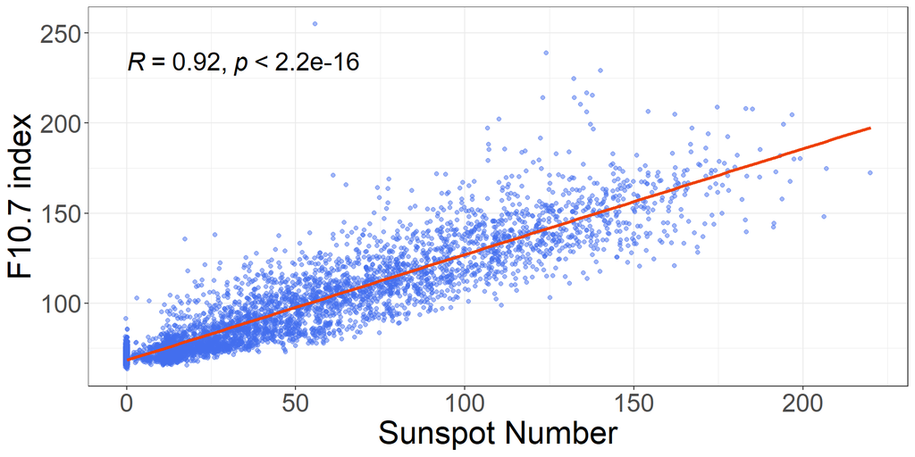

```r
brain_data %>%
  ggplot(aes(Sunspots, F10.7))+
  geom_jitter(alpha = 0.5, colour = "royalblue2", size = 1.5)+
  geom_smooth(method = "lm", se = FALSE, colour = "orangered2", linewidth = 1.2) +
  stat_cor(method = "pearson", label.x.npc = 0, label.y.npc = 0.9, size = 7)+
  labs(x = "Sunspot Number", y = "F10.7 index")+
  theme_custom
```

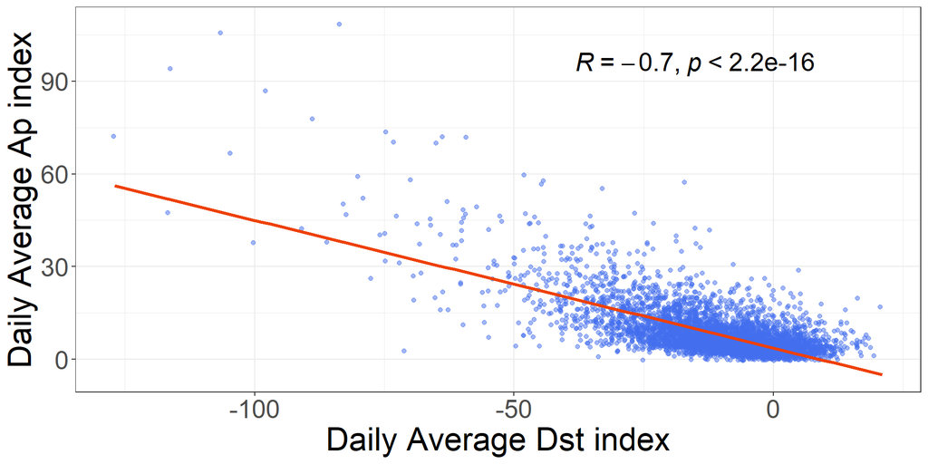

```r
brain_data %>%
  ggplot(aes(Dst_mean, Ap_mean))+
  geom_jitter(alpha = 0.5, colour = "royalblue2", size = 1.5)+
  geom_smooth(method = "lm", se = FALSE, colour = "orangered2", linewidth = 1.2) +
  stat_cor(method = "pearson", label.x.npc = 0.6, label.y.npc = 0.9, size = 7)+
  labs(x = "Daily Average Dst index", y = "Daily Average Ap index")+
  theme_custom
```

- A negative correlation was expected between the daily average temperature and pressure (r = -0.73).
- The F10.7 index and the number of sunspots show a high correlation (r = 0.92), as both reflect solar activity but are measured using different methods.
- The daily average Ap and Dst indices demonstrate a significant correlation (r = -0.70), as both reflect changes in the Earth’s geomagnetic field. However, the distribution of data along the trend line remains uneven.

Based on further analysis, the following variables will be excluded:

- **Pressure**: does not provide full coverage of the data throughout the study period and exhibits less variability compared to Temperature.
- **F10.7 Index**: has an incomplete data set and exhibits less variability compared to Sunspot count.
- The **Ap and Dst** geomagnetic activity indices will not be excluded.

## Solar cycles

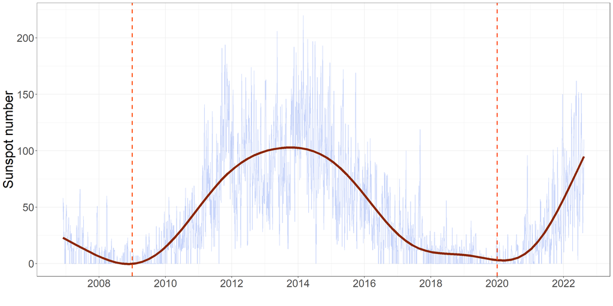

```r
brain_data %>%
  select(!c(Pressure, F10.7, Ap_mean)) %>%
  ggplot(aes(Date, Sunspots))+
  geom_line(alpha = 0.3, colour = "royalblue2")+
  geom_smooth(method = "gam", formula = y ~ s(x, k = 10),  se = FALSE,
              colour = "orangered4", linewidth = 2) +
  geom_vline(xintercept = as.Date("2009-01-01"),
             colour = "orangered", linewidth = 1, linetype = "dashed")+
  geom_vline(xintercept = as.Date("2019-12-31"),
             colour = "orangered", linewidth = 1, linetype = "dashed")+
  scale_x_date(date_breaks = "2 year", date_labels = "%Y")+
  labs(x = "", y = "Sunspot number")+
  theme_custom
```

The number of sunspots is directly linked to the solar activity cycles, as confirmed by the graph. For further analysis, it is advisable to focus separately on the period from 2009 to 2019, which covers the complete 24th solar activity cycle.

## Data Decomposition

Decomposition allows us to identify trends and cyclicity:

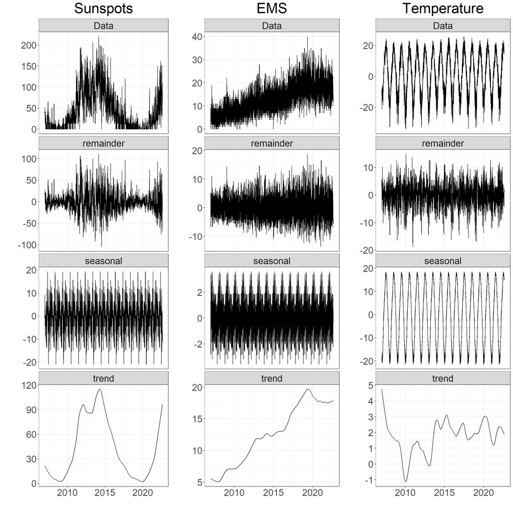

```r
ggarrange(

  brain_data %>% filter(Date >=  ymd("2007-01-01")) %>% pull(Sunspots) %>%
  ts(start = 2007, frequency = 365) %>% stl(s.window = "periodic") %>%
  autoplot() + theme_custom + ggtitle("Sunspots"),

  brain_data %>% filter(Date >=  ymd("2007-01-01")) %>% pull(EMS) %>%
  ts(start = 2007, frequency = 365) %>% stl(s.window = "periodic") %>%
  autoplot() + theme_custom + ggtitle("EMS"),

  brain_data %>% filter(Date >=  ymd("2007-01-01")) %>% pull(Temp_mean) %>%
  ts(start = 2007, frequency = 365) %>% stl(s.window = "periodic") %>%
  autoplot() + theme_custom + ggtitle("Temperature"),

  nrow = 1
)
```

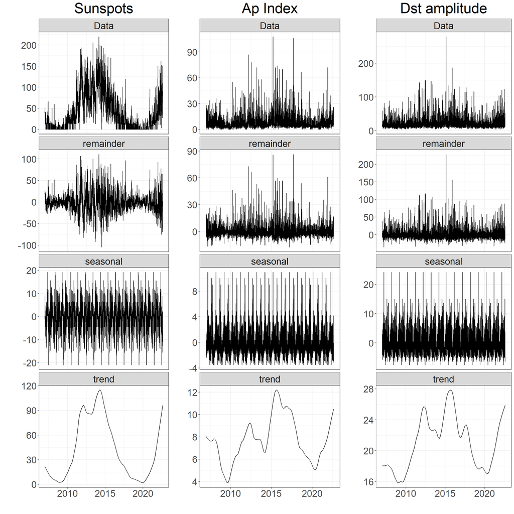

```r
ggarrange(

  brain_data %>% filter(Date >=  ymd("2007-01-01")) %>% pull(Sunspots) %>%
  ts(start = 2007, frequency = 365) %>% stl(s.window = "periodic") %>%
  autoplot() + theme_custom + ggtitle("Sunspots"),

  brain_data %>% filter(Date >=  ymd("2007-01-01")) %>% pull(Ap_mean) %>%
  ts(start = 2007, frequency = 365) %>% stl(s.window = "periodic") %>%
  autoplot() + theme_custom + ggtitle("Ap Index"),

  brain_data %>% filter(Date >=  ymd("2007-01-01")) %>% pull(Dst_var) %>%
  ts(start = 2007, frequency = 365) %>% stl(s.window = "periodic") %>%
  autoplot() + theme_custom + ggtitle("Dst amplitude"),

  nrow = 1
)
```

- After decomposing the **emergency medical call data**, a linear increase over time is observed. However, since 2020, a noticeable decrease is apparent, likely associated with the COVID-19 pandemic.
- Climatic data (especially **temperature**), after decomposition, show a clear cyclic pattern.
- The **daily Dst index** does not show any clear trends or cycles. However, the daily fluctuation **amplitude of the Dst index**, after decomposition, exhibits a trend similar to the dynamics of sunspot numbers. Nevertheless, since noise is the dominant component, the results should not be taken too seriously.

## Visualizing Association

### Trends: EMS & Sunspots

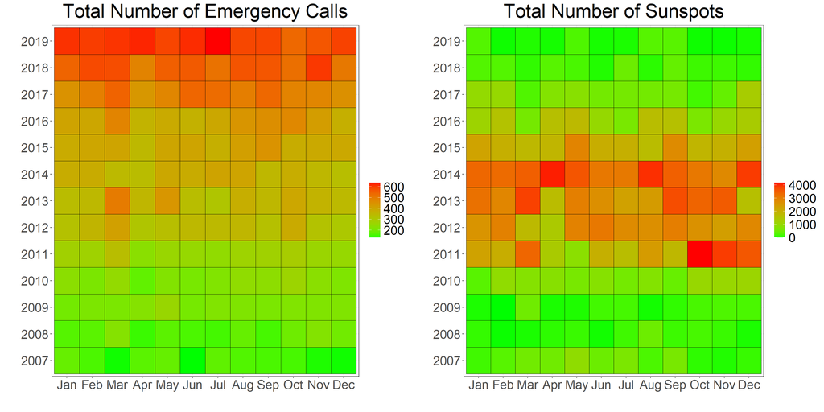

```r
ggarrange(
brain_data %>%
  filter(Date %within% interval(ymd("2007-01-01"), ymd("2019-12-31"))) %>%
  group_by(Year, Month) %>%
  summarise(EMS_month = sum(EMS, na.rm = TRUE), .groups = "drop") %>%
  ggplot(aes(x = Month, y = Year, fill = EMS_month)) +
  geom_tile(colour = "black") +
  scale_fill_gradient(low = "green", high = "red") +
  scale_x_discrete(labels = month.abb) +
  labs(x = "", y  = "", fill = "", title = "Total Number of Emergency Calls")+
  theme_custom,

brain_data %>%
  filter(Date %within% interval(ymd("2007-01-01"), ymd("2019-12-31"))) %>%
  group_by(Year, Month) %>%
  summarise(Sunspots_month = sum(Sunspots, na.rm = TRUE), .groups = "drop") %>%
  ggplot(aes(x = Month, y = Year, fill = Sunspots_month)) +
  geom_tile(colour = "black") +
  scale_fill_gradient(low = "green", high = "red") +
  scale_x_discrete(labels = month.abb) +
  labs(x = "", y  = "", fill = "", title = "Total Number of Sunspots")+
  theme_custom
)
```

### Dst ~ Sunspots

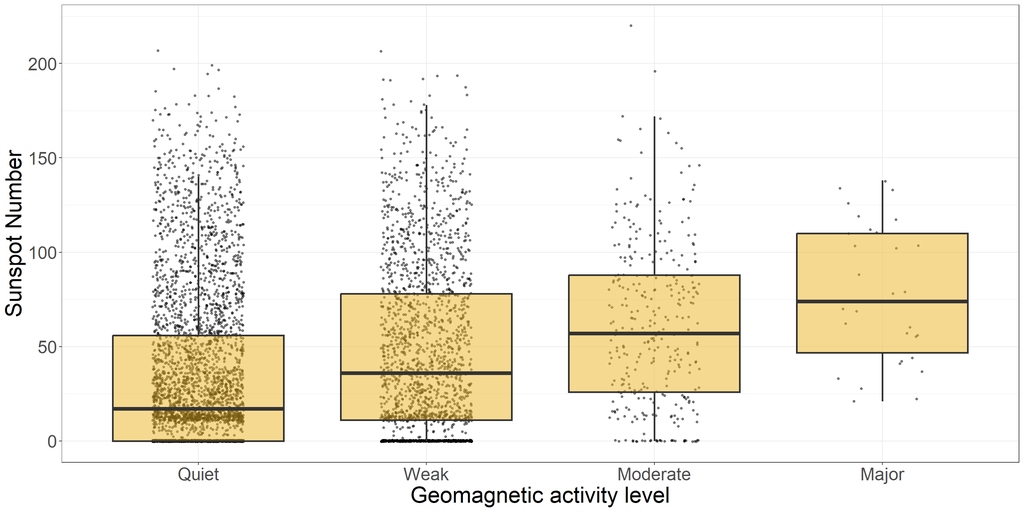

```r
brain_data %>%
  filter(Dst_level != "Severe") %>%
  mutate(Dst_level = fct_relevel(Dst_level, c("Quiet", "Weak", "Moderate", "Major", "Severe"))) %>%
  ggplot(aes(Dst_level, Sunspots))+
  geom_jitter(alpha = 0.5, size = 1, width = 0.2) +
  geom_boxplot(alpha = 0.5, outliers = FALSE, fill = "goldenrod2", linewidth = 1)+
  labs( x = "Geomagnetic activity level",  y = "Sunspot Number" ) +
  theme_custom
```

### DayOff ~ EMS

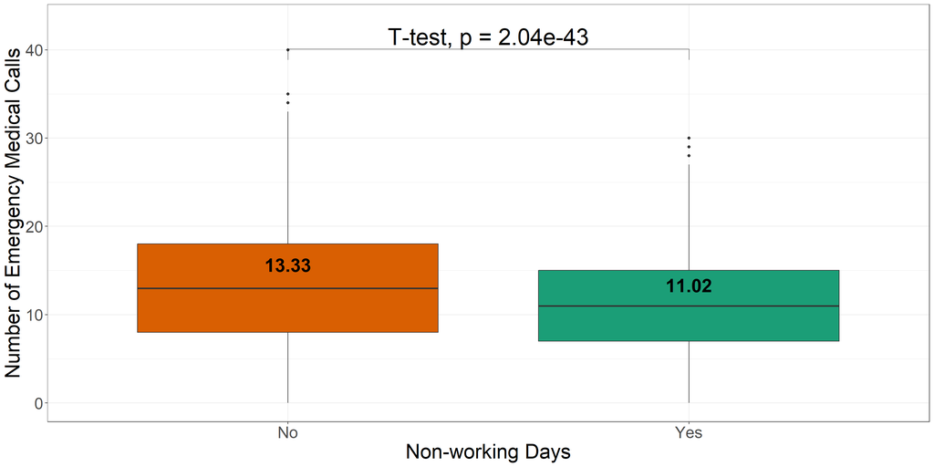

```r
mean_values <- brain_data %>%
  group_by(DayOff) %>%
  summarise(mean_EMS = round(mean(EMS, na.rm = TRUE), 2), .groups = "drop")

ggplot(brain_data, aes(x = DayOff, y = EMS)) +
  geom_boxplot(aes(fill = DayOff)) +
  geom_text(data = mean_values,
            aes(x = DayOff, y = mean_EMS, label = mean_EMS),
            color = "black", size = 8, fontface = "bold", vjust = -1) +
  scale_fill_brewer(palette = "Dark2", direction = -1)+
  scale_y_continuous(limits = c(NA, max(brain_data$EMS) + 3))+
  labs(y = "Number of Emergency Medical Calls", x = "Non-working Days")+
  theme_custom +
  theme(legend.position = "none")+
  stat_pvalue_manual(t_test(data = brain_data,  EMS ~ DayOff),
                     label = "T-test, p = {p}",
                     size = 10,
                     y.position = max(brain_data$EMS) + 0.1)
```

- The difference between the average EMS values for weekdays and weekends is statistically significant.
- The average EMS value is higher on weekdays (13.33) compared to weekends (11.02).

### Season ~ EMS

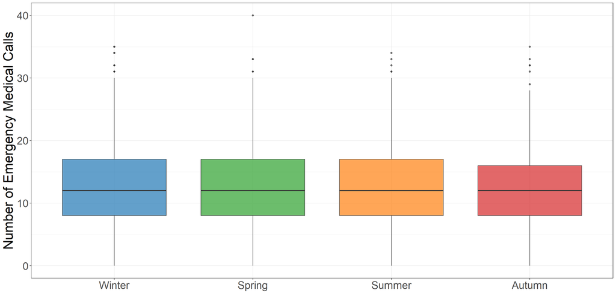

```r
brain_data %>%
mutate(Season = fct_relevel(Season, c("Winter", "Spring", "Summer", "Autumn"))) %>%
ggplot(aes(x = Season, y = EMS, fill = Season)) +
  geom_boxplot(alpha = 0.7, show.legend = FALSE) +
  scale_fill_manual(
    values = c("Winter" = "#1f77b4", "Spring" = "#2ca02c", "Summer" = "#ff7f0e","Autumn" = "#d62728")) +
  labs(y = "Number of Emergency Medical Calls", x = "")+
  theme_custom
```

```r
brain_data %>%
  pairwise_t_test(EMS ~ Season, p.adjust.method = "holm") %>%
  transmute(`Group 1` = group1, `Group 2` = group2,
            `p-value` = p, `p.adjusted` = p.adj) %>%
  flextable()
```

| Group 1 | Group 2 | p-value | p.adjusted |
| --- | --- | --- | --- |
| Autumn | Spring | 0.0162 | 0.0969 |
| Autumn | Summer | 0.1300 | 0.5200 |
| Spring | Summer | 0.3670 | 1.0000 |
| Autumn | Winter | 0.0259 | 0.1290 |
| Spring | Winter | 0.8650 | 1.0000 |
| Summer | Winter | 0.4670 | 1.0000 |

The distribution of emergency medical service calls across seasons is statistically insignificant (**paired t-test with Holm p-value adjustment method: p.adjusted > 0.05**).

### Geomagnetic indices

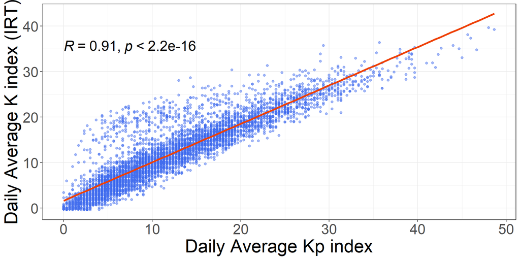

```r
brain_data %>%
  drop_na(Kp_Sum, K_Sum) %>%
  ggplot(aes(Kp_Sum, K_Sum))+
  geom_jitter(alpha = 0.5, colour = "royalblue2", size = 1.5)+
  geom_smooth(method = "lm", se = FALSE, colour = "orangered2", linewidth = 1.2) +
  stat_cor(method = "pearson", label.x.npc = 0, label.y.npc = 0.9, size = 7)+
  labs(x = "Daily Average Kp index", y = "Daily Average K index (IRT)")+
  theme_custom
```

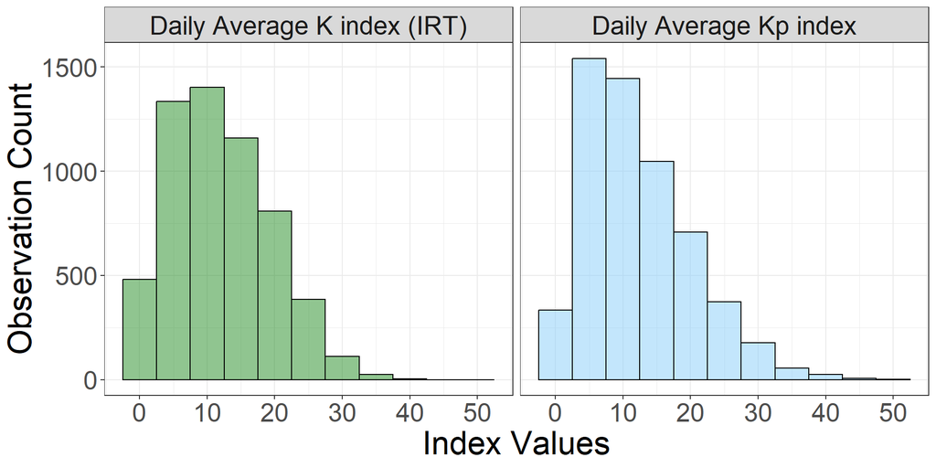

```r
brain_data %>%
  drop_na(Kp_Sum, K_Sum) %>%
  pivot_longer(cols = c(Kp_Sum, K_Sum), names_to = "index") %>%
  ggplot() +
  geom_histogram(aes(x = value, fill = index),
                 binwidth = 5, colour = "black", alpha = 0.5, position = "identity", show.legend = FALSE) +
  scale_fill_manual(
    values = c("K_Sum" = "#228B22", "Kp_Sum" = "#87CEFA") )+
  scale_x_continuous(breaks = seq(0, 50, 10))+
  labs( x = "Index Values", y = "Observation Count", fill = "Index Type") +
  theme_custom +
  facet_wrap(~index, labeller = labeller(index = c("K_Sum" = "Daily Average K index (IRT)",
                                                   "Kp_Sum" = "Daily Average Kp index")))
```

Daily Average Kp index and Daily Average K index (IRT) show a strong correlation **(r = 0.91)**. However, K index (IRT) has a smaller range and a more uniform distribution compared to Kp index.